# Software improvements to speedyBBT, an R package for comparative judgment

Christine Stawitz, Rowland Seymour, and Heather Turner

## Introduction

- Comparative judgment data analysis tool
- `speedyBBT` package fits Bayesian Bradley-Terry models to the data
- New version of `speedyBBT` adds more user-friendly features
- A website with more examples to help users get started with the package

## Definitions

- Items being compared are called “items”
- The outcome of a comparison is called a “win” or “loss”
- Estimated parameters are called “qualities” of the players/items
  - Designated by lambda ($\lambda$)
- Many options for model-fitting including prior information, parameters, and player/item-specific advantages

## Model fitting pipeline

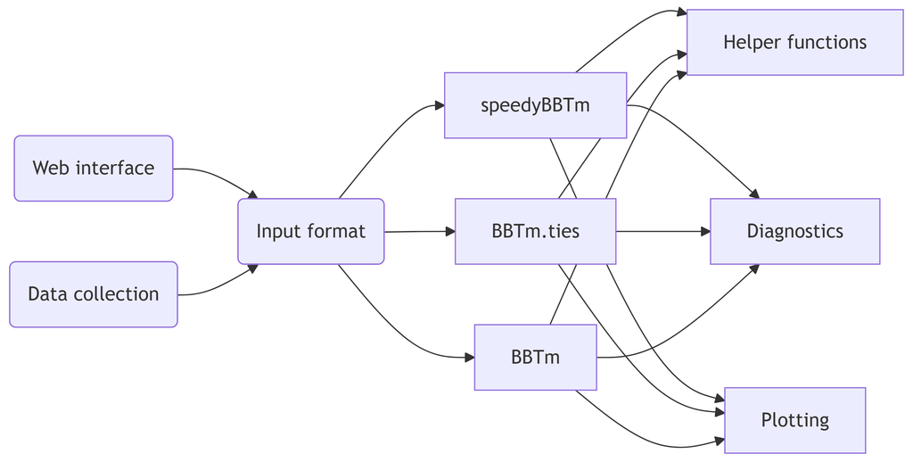

## Comparative judgment interface

[figure not shown]

https://cjdemo.bham.ac.uk/rank

## Structure of data items

```r
library(speedyBBT)
names(forcedMarriage)
```

```
[1] "comparisons"     "wards"           "adjacencyMatrix"
```

```r
kable(forcedMarriage$comparisons[1:5, ])
```

| user | time | win | lost |
| --- | --- | --- | --- |
| 1 | 16:08:26.316839 | 67 | 31 |
| 1 | 16:08:47.888894 | 19 | 9 |
| 1 | 16:09:14.093517 | 18 | 74 |
| 1 | 16:09:23.666987 | 56 | 68 |
| 1 | 16:09:42.930976 | 50 | 66 |

## Adjacency matrix

- This is a square matrix with rows and columns corresponding to the players/items
- We assume adjacent items are more similar than non-adjacent items
- Used for prior variance-covariance matrix

```r
kable(forcedMarriage$adjacencyMatrix[1:5,1:5] )
```

| 0 | 0 | 0 | 0 | 0 |
| --- | --- | --- | --- | --- |
| 0 | 0 | 1 | 0 | 0 |
| 0 | 1 | 0 | 0 | 0 |
| 0 | 0 | 0 | 0 | 0 |
| 0 | 0 | 0 | 0 | 0 |

# Model fitting functions

## Model options

- Several forms of Bayesian Bradley-Terry model
- `speedyBBTm` improves speed without ties or advantages
- `BBTm.ties` allows for ties in comparisons
- `BBTm` allows for comparison-specific and player-specific advantages

## Using a model fitting function

```r
expA <- expm::expm(forcedMarriage$adjacencyMatrix)
prior.var <- diag(diag(expA)^-0.5) %*% expA %*% diag(diag(expA)^-0.5)

set.seed(432)

forcedMarriageModel <- speedyBBTm(
  outcome = rep(1, length(forcedMarriage$comparisons$win)),
  item1 = forcedMarriage$comparisons$win,
  item2 = forcedMarriage$comparisons$lost,
  item.prior.var = prior.var,
  n.iter = 1000,
  burn.in = 100
)
```

## With advantage

```r
wimbledonModel <- BBTm(
  outcome = wimbledon$matches$outcome,
  item2 = wimbledon$matches$loser,
  item1 = wimbledon$matches$winner,
  advantage = wimbledon$matches$secondWeek,
  formula = ~ rank + points,
  data = wimbledon$players,
  n.iter = 10, burn.in = 1, verbose = FALSE
)
```

# Processing model output

## Output model uses R to improve output processing

```r
class(forcedMarriageModel)
```

```
[1] "mcmc"
```

- Standard functions like `summary()` and `plot()`
- Functions developed to work with `mcmc` objects from the `{coda}` package
- Common plotting functions provided by packages like `{bayesplot}`

```r
pretty_names <- gsub(" (City ward)", "", forcedMarriage$wards$NAME, fixed = TRUE)
pretty_names <- gsub(" (County ward)", "", pretty_names, fixed = TRUE)
quality_table <- plot_qualities(forcedMarriageModel,
item_names = pretty_names, flip = TRUE)
```

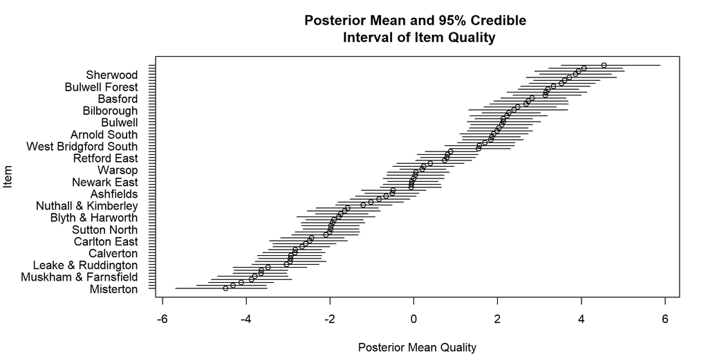

## Helper function for model output

- `parameter()` returns a vector of posterior samples for a given parameter

```r
lambda <- parameter(forcedMarriageModel, "lambda", c(10,20))
hist(lambda, main = "Posterior distribution of estimated abilities", xlab = "lambda")
```

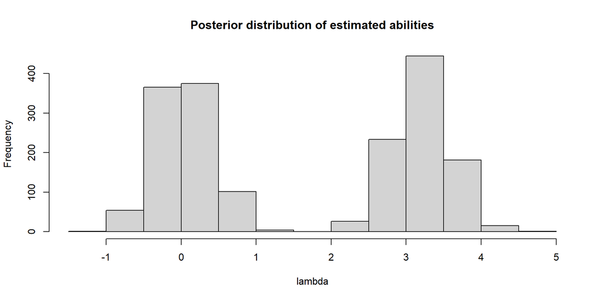

## Compatibility with other plotting packages

- Allows for easy plotting of posterior distributions and diagnostics

```r
library(bayesplot)
bayesplot::mcmc_intervals(forcedMarriageModel,
pars = c("lambda[10]", "lambda[20]", "lambda[30]", "lambda[40]"))
```

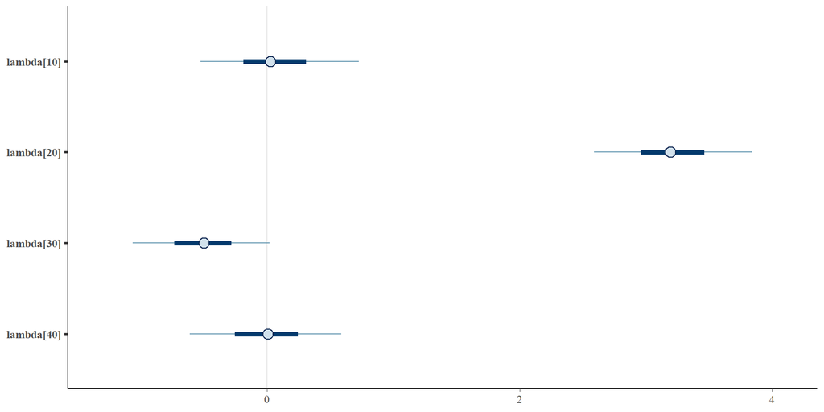

# Improved documentation

## `pkgdown` site

[interactive chart not shown]

## New vignettes

[interactive chart not shown]

## Summary

- `speedyBBT` provides functions for analysis of comparative judgment data
- New model fitting functions and output format improve usability
- Improved test coverage and documentation

# Thank you!

[figure not shown]

[figure not shown]

This presentation